# Analysis of Terascope Benchmarking Data

Mark R. Tyrrell

23/01/2019

## 1. Introduction

Visualization methods panoramic images show potential for visualizing multiscale urban data. accessible route to supercomputer visualizations on many low cost devices. Visual supercomputing deployed 14 PFlop cloud supercomputer, larger than any GPU HPC system in UK. cost in total for one result (a scaling graph) ~£20,000 using > £10 million computer. Azure improved (from K80 to V100) during the project, we immediately benefited. provides access to performance approx. 20 years ahead of current desktop systems.

## 2. Background

Terapixel images offer an intuitive, accessible way to present information sets to stakeholders, allowing viewers to interactively browse big data across multiple scales. The challenge we addressed here is how to deliver the supercomputer scale resources needed to compute a realistic terapixel visualization of the city of Newcastle upon Tyne and its environmental data as captured by the Newcastle Urban Observatory.

Our solution is a scalable architecture for cloud-based visualization that we can deploy and pay for only as needed. The three key objectives of this work are to: create a supercomputer architecture for scalable visualization using the public cloud; produce a terapixel 3D city visualization supporting daily updates; undertake a rigorous evaluation of cloud supercomputing for compute intensive visualization applications.

We demonstrate that it is feasible to produce a high quality terapixel visualization using a path tracing renderer in under a day using public IaaS cloud GPU nodes. Once generated the terapixel image supports interactive browsing of the city and its data at a range of sensing scales from the whole city to a single desk in a room, accessible across a wide range of thin client devices.

Problem Description

The dataset below was created from application checkpoint and system metric output from the production of a terapixel image. There are a variety of problems which can be addressed using the TeraScope dataset. Each will commence with an exploratory data analysis. Examples of questions you may wish to be able to answer through the EDA process are as follows:

Which event types dominate task runtimes? What is the interplay between GPU temperature and performance? What is the interplay between increased power draw and render time? Can we quantify the variation in computation requirements for particular tiles? Can we identify particular GPU cards (based on their serial numbers) whose performance differs to other cards? (i.e. perpetually slow cards). What can we learn about the efficiency of the task scheduling process? A project may focus entirely on the EDA process, or you may also wish to develop a data product to allow interactive exploration of the data. For example, you could develop a Shiny dashboard to display the results of your analysis into render performance and system operation, displaying timelines of execution based on the application checkpoint data.

## 3. Methodology

Data analysis was conducted using the R programming language and the R Studio IDE, with the report composed in Rmarkdown. The **ProjectTemplate** library was used to organise the project and ensure reproducability. Version control was managed using git and Github.

An archived folder is available containing the original Rmarkdown .rmd file and git log. The folder is structured for standard data mining projects, including subfolders for data, cache, munge and source files. As the data analysis involves operations which require extended processing time, key objects have been cached as .Rdata files. The objects are called along the progression of the script (and Rmarkdown report), while the original code is included in the munge folder. Detailed instructions for reproducing the analysis are included in the main README file.

The original csv data files are too large for Github at 300+ MB. Therefore they are not included in the archived project folder. A download link can be found in the README file.

### 3.1 Data Understanding

The data made available for this analysis consists of 3 tabular data files in comma-separated value (.csv) format covering multiple aspects of the terapixel rendering process. The data files are detailed below.

#### 2.1.1 Application Checkpoints (application-checkpoints.csv 111.2MB)

This file contains 660,400 observations over 6 variables detailing application checkpoint events throughout the execution of the render job.

1. **timestamp** Timestamp of observation entry
2. **hostname** Unique hostname of the virtual machine auto-assigned by the Azure batch system (Total unique: 1024)
3. **eventName** Name of the event occuring within the rendering application. Possible Values:
   - **Tiling** Tiling is where post processing of the rendered tile is taking place
   - **Saving** Config Saving Config is simply a measure of configuration overhead
   - **Render** Render is when the image tile is is being rendered
   - **TotalRender** TotalRender is the entire task
   - **Uploading** Uploading is where the output from post processing is uploaded to Azure Blob Storage
4. **eventType** Possible Values: **START**, **STOP**
5. **jobId** ID of the Azure batch job (Total: 3 one for each level 4, 8 and 12)
6. **taskId** ID of the Azure batch task (Total: 65793 level 4 1x1; level 8 16x16; level 12 256x256)

#### 3.1.2 GPU (gpu.csv 208.7MB)

This file contains 1,543,681 observations over 8 variables detailing metrics that were output regarding the status of the GPU on the virtual machine.

1. **timestamp** Timestamp of observation entry
2. **hostname** Unique hostname of the virtual machine auto-assigned by the Azure batch system (Total unique: 1024)
3. **gpuSerial** Unique serial number of the physical GPU card (Total unique: 1024)
4. **gpuUUID** Unique system id assigned by the Azure system to the GPU unit (Total unique: 1024)
5. **powerDrawWatt** Power draw of the GPU in watts
6. **gpuTempC** Temperature of the GPU in Celsius
7. **gpuUtilPerc** Percent utilisation of the GPU Core(s)
8. **gpuMemUtilPerc** Percent utilisation of the GPU memory

#### 3.1.3 Task X Y (task-x-y.csv 6.2MB)

This file contains 65,793 observations over 5 variables detailing the tile x,y co-ordinates of which part the image was being rendered for each task.

1. **jobId** ID of the Azure batch job (Total: 3 one for each level 4, 8 and 12)
2. **taskId** ID of the Azure batch task (Total: 65793 level 4 1x1; level 8 16x16; level 12 256x256)
3. **x** X co-ordinate of the image tile being rendered (Total unique: 256)
4. **y** Y co-ordinate of the image tile being rendered (Total unique: 256)
5. **level** The visualisation created is a zoomable “google maps style” map. In total we create 12 levels. Level 1 is zoomed right out and level 12 is zoomed right in. You will only see levels 4, 8 and 12 in the data as the intermediate level are derived in the tiling process.

### 3.2 Data Preparation

The csv files were read into R and reviewed. Data types were changed as required (eg. timestamps, factors to char etc). In the case of the GPU dataset, the extraneous column **gpuUUID** was dropped, as it was redundant with **gpuSerial** as a unique identifier. The Task X Y dataset was fully merged into the Application Checkpoint dataset, as it contained only 3 unique columns. The resulting object **app_task** was cached along with the **gpu** object for the GPU dataset, after checking for NAs. These cached objects form the basis of the analysis.

## 4 Exploratory Data Analysis

The performance data over 10 minutes for a sample GPU (S/N: 323617042631) is displayed in Figure 1. The cycles for each tiling job can be clearly seen in the plot for each metric. Each tiling job took appears to take approximately 40 seconds.

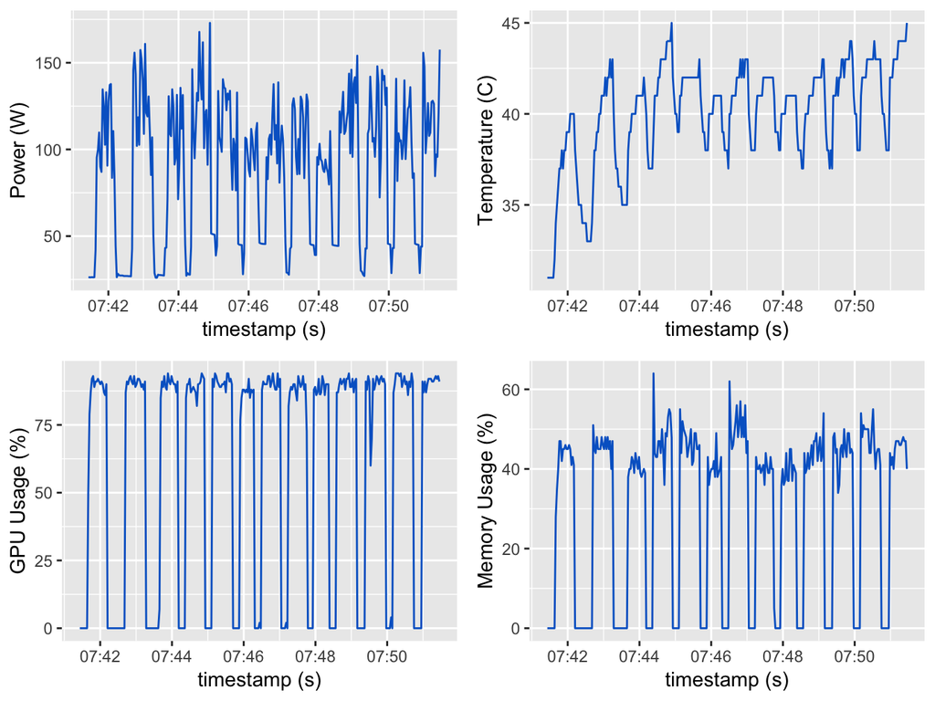

Sample GPU Performance Metrics over Time

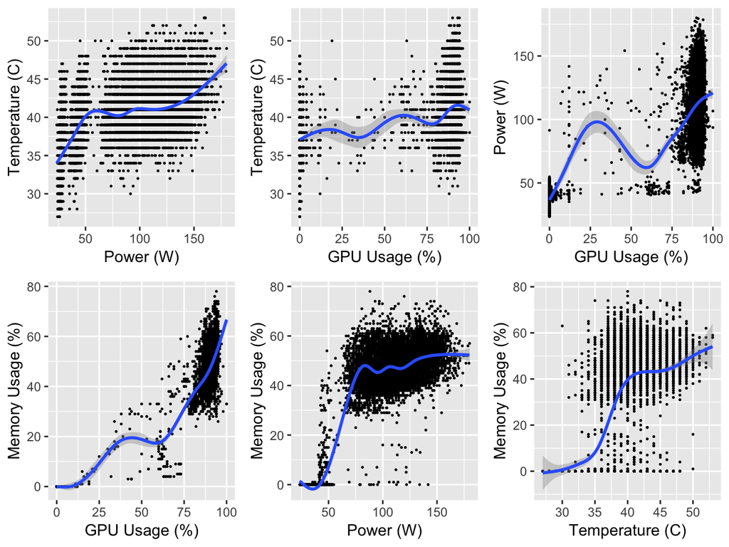

GPU Performance Metrics Correlation

Task Runtime Mean Durations (Level 12)

| Event Name | mean duration (s) | n |
| --- | --- | --- |
| Render | 41.21 | 65536 |
| Saving Config | 0.00 | 65536 |
| Tiling | 0.97 | 65536 |
| TotalRender | 42.58 | 65536 |
| Uploading | 1.37 | 65536 |

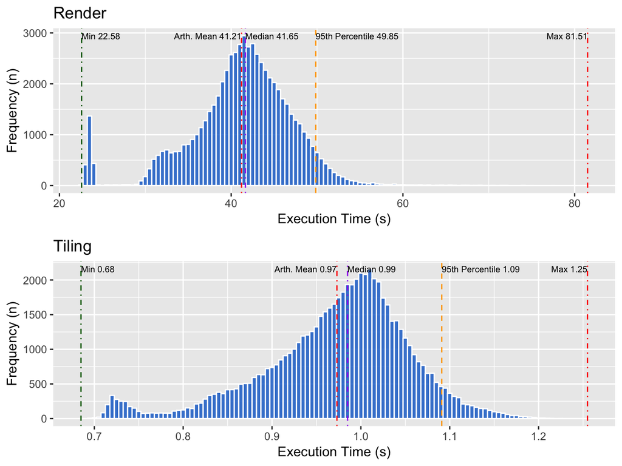

Distribution by Execution Time: Render & Tiling

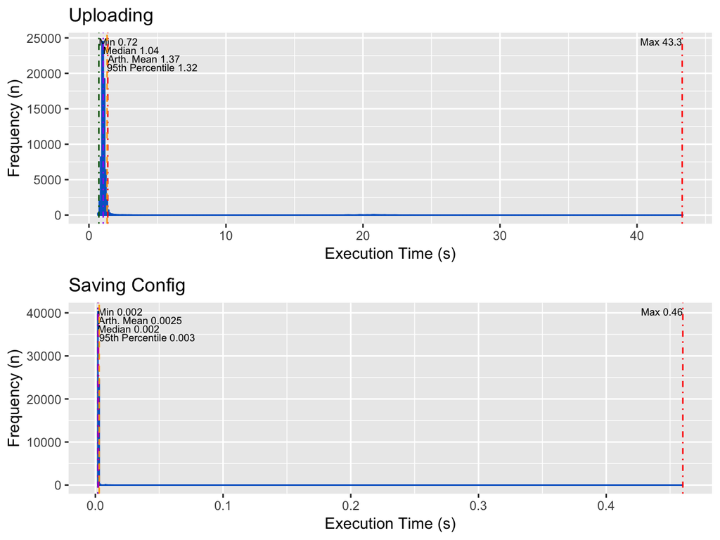

Distribution by Execution Time: Uploading & Save Config

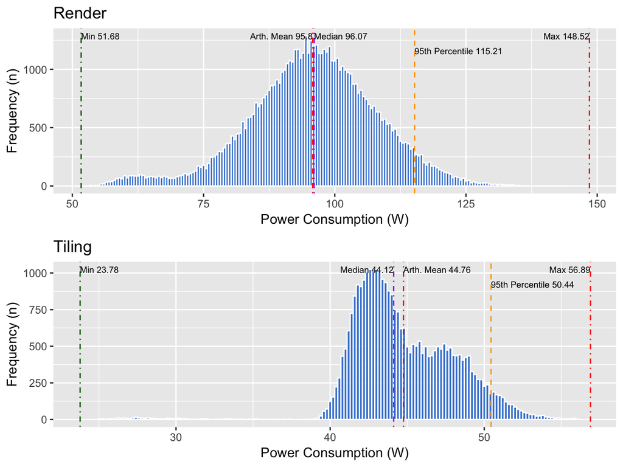

Distribution by Power Consumption: Render & Tiling

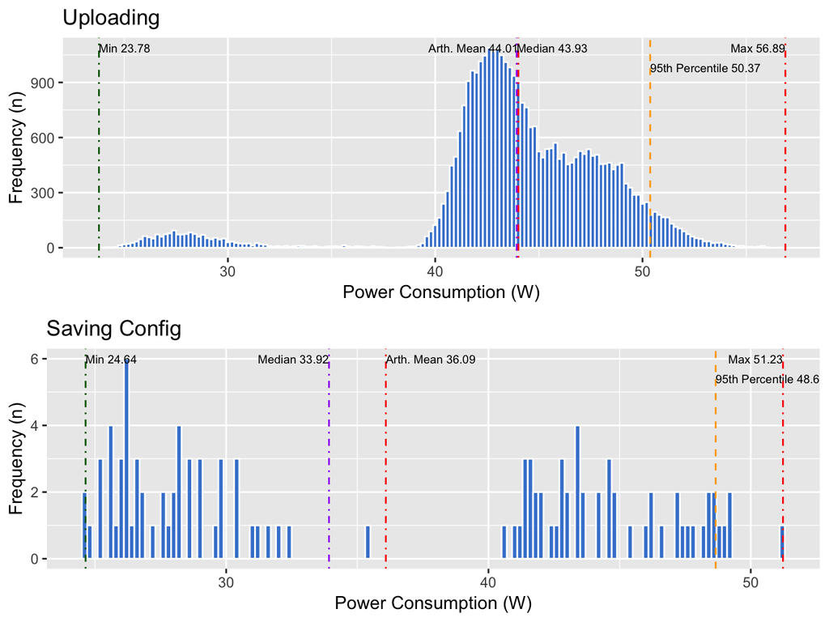

Distribution by Power Consumption: Uploading & Save Config

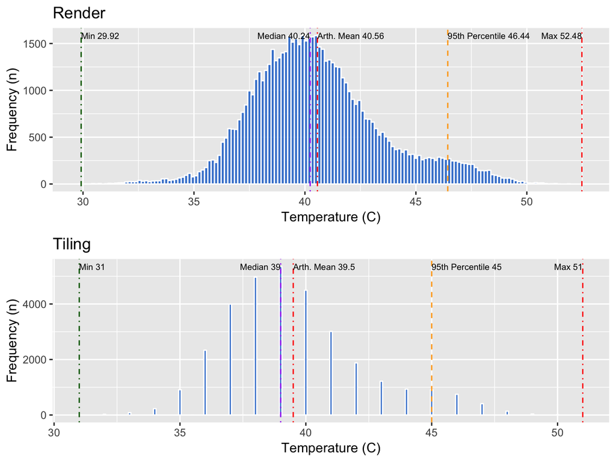

Distribution by Temperature: Render & Tiling

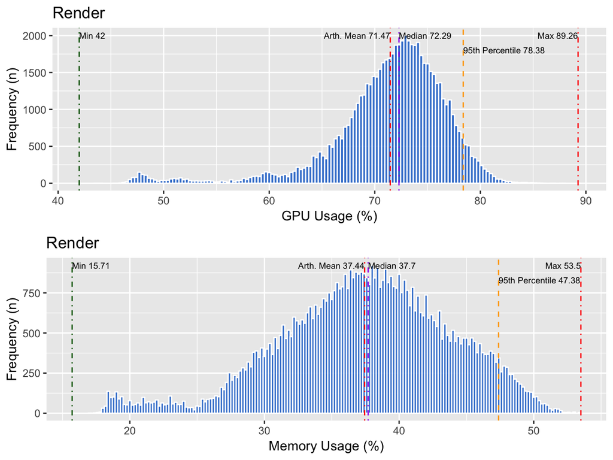

Distribution by GPU & Memory: Render

[figure not shown]

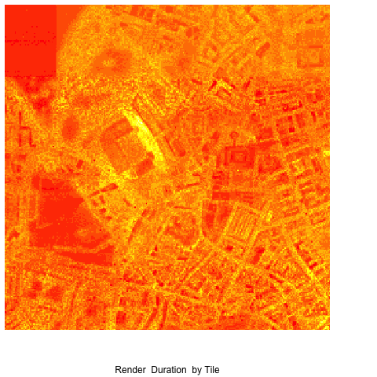

```r
knitr::include_graphics(path = "/Users/MT/Desktop/DS_Projects/CSC8634_CC_Project/graphs/p24.png")
```